# trab_final

## Um Framework vetorial para a interpretação e computação estatística e probabilística

## Sumário

- Introdução
  - Introdução a Probabilidade
    - Probabilidade
      - Espaço Amostral e Eventos
      - Axiomas de Probabilidade
      - Probabilidade Condicional
      - Regra do Produto e Probabilidade Conjunta
      - Regra da Soma e Probabilidade Marginal
      - Teorema de Bayes
    - Variáveis Aleatórias
      - Variáveis Aleatórias Discretas
      - Variáveis Aleatórias Contínuas
      - Esperança e Momentos
      - Funções de Distribuição
    - Distribuições de Probabilidade
      - Distribuições Discretas
        - Distribuição de Bernoulli
        - Distribuição Binomial
        - Distribuição de Poisson
      - Distribuições Contínuas
        - Distribuição Normal (Gaussiana)
        - Distribuição Exponencial
  - Introdução à Estatística
    - População e Amostra
    - Estatística Descritiva
      - Média
      - Variância e Desvio Padrão
      - Covariância e Coeficiente de Correlação
    - Estatística Inferencial
      - Estimadores
      - Estimadores de Máxima Verossimilhança
  - Espaço Vetorial de Variáveis Aleatórias
    - Variáveis Aleatórias como Vetores
    - Vetor Aleatório
      - Definição Matemática
      - Distribuição Normal Vetorial
      - Dedução da Distribuição Normal Vetorial
    - Ilustração Visual
  - PCA e SVD: Análise de Componentes Principais e Decomposição em Valores Singulares
    - PCA (Análise de Componentes Principais)
      - Formulação Matemática
      - Ilustração Visual
    - SVD (Decomposição em Valores Singulares)
    - Relação entre PCA e SVD
      - PCA como uma Aplicação da SVD
      - Relação Matemática entre PCA e SVD
  - Regressão Linear e o estimador de mínimos quadrados
    - Introdução à Regressão Linear em Termos Estatísticos
    - Função de Custo da Regressão Linear e Máxima Verossimilhança
  - Regressão Ridge (Tikhonov Regularization)
  - Referências

## Introdução

Na atualidade quase todos os campos do conhecimento bebem, ou pelo menos passam, pela área computacional. Dos estudos humanos até os fisico-matemáticos o uso de software e algoritmos para resolução de problemas, ou ao menos como ferramenta auxiliar de estudo e análise se tornou padrão-ouro no meio acadêmico e na indústria. Não obstante, um dos cursos de conhecimento que mais ganharam destaque graças a penetração da tecnologia e do aumento do poder computacional foi a área de estatística, que com os as novas ferramentas foi capaz de expandir seu alcance e atingir patamares de relevância inéditos na área.

Uma derivação desse ganho foi o aumento de expressividade e de utilidade de modelos de aprendizado de máquinas, que fundamentalmente possuem forte embasamento estatístico e sempre foram limitados pelo alta complexidade de suas execuções e agora ocupa uma posição de vanguarda, porém como toda melhora ela também acompanha um custo. A implementação de desenvolvimento dos algoritmos e softwares que servem de ferramental para realização dessas aplicações veio a se tornar uma das mais difíceis tarefas, contando com linhas de estudos exclusivas para seu entendimento. Como cerne desse novo mundo que surge em cima da computação, encontra-se conhecimentos matemáticos que precisaram ser incorporados pela teoria latente para poder contemplar uma nova abordagem e interpretação do problema de forma aplicada e otimizada ao maquinário. Para isso, não só a estatística e probabilidade, mas quase todas as ciências exatas começaram a ganhar intuição e interpretações do ponto de vista algébrico-espacial e possuir sua própria representação e modelagem dentro da algebra Linear.

A ideia desse estudo é oferecer ao leitor uma abordagem do ponto de vista geométrico e algébrico da estatística e da probabilidade e como estas se traduzem em problemas que são mais facilmente resolvidos pelo computador, e como noções próprias da área agora possuem uma nova roupagem matricial e geométrica que abrem novas portas a mesma. Aqui abordaremos dos conceitos básicos da estatística e probabilidade, até quando, e como, estas se misturam com a noção de vetores e de espaços vetoriais. Demonstraremos também o funcionamento e a tradução entre as duas linguagens - algebra linear e prob. e est. - para diferentes algoritmos e ferramentas que foram descobertos pelas duas sob pontos de vistas distintos. Por fim, almeja-se oferecer ao leitor que se interessar, uma sólida fundação e caminho para entendimento dos campos dos estudos estocásticos sob um framework da algebra linear.

## Introdução a Probabilidade

### Probabilidade

Probabilidade é uma medida numérica que quantifica a chance ou a possibilidade de um evento ocorrer. Denotamos a probabilidade de um evento A como P(A), onde P é a função de probabilidade.

#### Espaço Amostral e Eventos

Em probabilidade, trabalhamos com um espaço amostral, denotado por Ω, que é o conjunto de todos os resultados possíveis de um experimento aleatório. Um evento é um subconjunto do espaço amostral, que consiste em um ou mais resultados possíveis.

#### Axiomas de Probabilidade

A teoria das probabilidades é fundamentada em três axiomas:

1. **Axioma da não-negatividade**: Para qualquer evento A, a probabilidade de A é um número não negativo: P(A) ≥ 0.
2. **Axioma da aditividade**: Para qualquer sequência de eventos mutuamente exclusivos A₁, A₂, ..., a probabilidade da união dos eventos é igual à soma das probabilidades individuais: P(A₁ ∪ A₂ ∪ ...) = P(A₁) + P(A₂) + ...
3. **Axioma da normalização**: A probabilidade do espaço amostral completo Ω é igual a 1: P(Ω) = 1.

A partir desses axiomas, podemos deduzir várias propriedades e teoremas da teoria das probabilidades.

#### Probabilidade Condicional

A probabilidade condicional é a probabilidade de um evento ocorrer, dado que outro evento já ocorreu. Denotamos a probabilidade condicional de A dado B como P(A|B). A fórmula para calcular a probabilidade condicional é: P(A|B) = P(A ∩ B) / P(B)

#### Regra do Produto e Probabilidade Conjunta

A regra do produto é usada para calcular a probabilidade conjunta de dois eventos A e B, ou seja, a probabilidade de ambos os eventos ocorrerem simultaneamente. A fórmula para a probabilidade conjunta é:

P(A ∩ B) = P(A|B) * P(B)

#### Regra da Soma e Probabilidade Marginal

A regra da soma é usada para calcular a probabilidade de um evento ocorrer, considerando diferentes cenários ou possibilidades. A fórmula para a probabilidade de um evento A é dada pela regra da soma: $$ P(A) = ∑ P(A ∩ Bᵢ) $$ onde Bᵢ são eventos mutuamente exclusivos que cobrem todo o espaço amostral.

#### Teorema de Bayes

O Teorema de Bayes é uma ferramenta importante na teoria das probabilidades para atualizar a probabilidade de um evento dado o conhecimento de outro evento relacionado. A fórmula do Teorema de Bayes é:

$$ P(A|B) = (P(B|A) * P(A)) / P(B) $$

onde P(A) e P(B) são as probabilidades marginais e P(B|A) é a probabilidade condicional.

### Variáveis Aleatórias

Uma variável aleatória é uma função que associa um número real a cada resultado de um experimento aleatório. Ela mapeia os resultados do espaço amostral para valores numéricos, permitindo a quantificação probabilística dos eventos.

#### Variáveis Aleatórias Discretas

Uma variável aleatória discreta assume um conjunto finito ou infinito contável de valores possíveis. A função de probabilidade de uma variável aleatória discreta, denotada por P(X), atribui probabilidades a cada valor possível da variável aleatória.

A função de probabilidade de uma variável aleatória discreta deve satisfazer as seguintes propriedades:

1. **Não-negatividade**: A probabilidade de um valor da variável aleatória é não negativa: $P(X = x) ≥ 0$ para todos os valores de x.
2. **Normalização**: A soma das probabilidades de todos os valores possíveis é igual a 1: $∑ P(X = x) = 1$, onde a soma é realizada sobre todos os valores de x.

A partir da função de probabilidade, podemos calcular a função de distribuição acumulada (FDA) de uma variável aleatória discreta, que fornece a probabilidade acumulada de obter um valor menor ou igual a um determinado valor.

#### Variáveis Aleatórias Contínuas

Uma variável aleatória contínua pode assumir qualquer valor em um intervalo contínuo. A função densidade de probabilidade (FDP) de uma variável aleatória contínua, denotada por f(x), descreve a distribuição de probabilidade ao longo do intervalo.

A função densidade de probabilidade deve satisfazer as seguintes propriedades:

1. **Não-negatividade**: A densidade de probabilidade é não negativa para todos os valores de x: $f(x) ≥ 0$.
2. **Normalização**: A área sob a curva da densidade de probabilidade é igual a 1: $∫ f(x) dx = 1$, onde a integral é realizada sobre todos os valores de x.

A partir da função densidade de probabilidade, podemos calcular a função de distribuição acumulada (FDA) de uma variável aleatória contínua, que fornece a probabilidade acumulada de obter um valor menor ou igual a um determinado valor.

#### Esperança e Momentos

A esperança (valor esperado) de uma variável aleatória é uma medida numérica que representa o valor médio esperado da variável. Para uma variável aleatória discreta, a esperança é calculada como a soma ponderada dos valores possíveis, multiplicados pelas probabilidades correspondentes.

Para uma variável aleatória contínua, a esperança é calculada como a integral ponderada dos valores possíveis, multiplicados pelas densidades de probabilidade correspondentes.

Os momentos de uma variável aleatória são medidas estatísticas que descrevem sua distribuição. O momento de ordem r é dado por $E[X^r]$ para uma variável aleatória X.

#### Funções de Distribuição

As funções de distribuição são usadas para caracterizar completamente uma variável aleatória. A função de distribuição acumulada (FDA) é uma função que fornece a probabilidade de obter um valor menor ou igual a um determinado valor.

Para uma variável aleatória discreta, a FDA é dada pela soma acumulada das probabilidades. Para uma variável aleatória contínua, a FDA é dada pela integral acumulada da densidade de probabilidade.

Esses conceitos fundamentais das variáveis aleatórias fornecem a base para a análise probabilística de eventos e a modelagem de incertezas em problemas estatísticos.

As funções de distribuição são usadas para caracterizar completamente uma variável aleatória. A função de distribuição acumulada (FDA) é uma função que fornece a probabilidade de obter um valor menor ou igual a um determinado valor.

Para uma variável aleatória discreta, a FDA é dada pela soma acumulada das probabilidades. Para uma variável aleatória contínua, a FDA é dada pela integral acumulada da densidade de probabilidade.

Esses conceitos fundamentais das variáveis aleatórias fornecem a base para a análise probabilística de eventos e a modelagem de incertezas em problemas estatísticos.

### Distribuições de Probabilidade

Uma distribuição de probabilidade descreve a forma como os valores de uma variável aleatória estão distribuídos. Ela especifica as probabilidades associadas a cada possível resultado ou intervalo de valores.

#### Distribuições Discretas

##### Distribuição de Bernoulli

A distribuição de Bernoulli modela um experimento aleatório que tem dois resultados possíveis, geralmente rotulados como sucesso (1) ou fracasso (0). A função de probabilidade de uma variável aleatória com distribuição de Bernoulli é dada por: $$ P(X = x) = p^x * (1 - p)^(1 - x) $$ onde x assume os valores 0 ou 1, e p é a probabilidade de sucesso.

##### Distribuição Binomial

A distribuição binomial descreve o número de sucessos em uma sequência de experimentos independentes e identicamente distribuídos (i.i.d.) com probabilidade de sucesso p. A função de probabilidade de uma variável aleatória com distribuição binomial é dada por: $$ P(X = k) = C(n, k) * p^k * (1 - p)^(n - k) $$ onde n é o número de experimentos, k é o número de sucessos, p é a probabilidade de sucesso e C(n, k) é o coeficiente binomial.

##### Distribuição de Poisson

A distribuição de Poisson descreve o número de eventos que ocorrem em um intervalo de tempo ou espaço fixo, quando os eventos ocorrem independentemente com uma taxa média conhecida. A função de probabilidade de uma variável aleatória com distribuição de Poisson é dada por:

$$ P(X = k) = (e^(-λ) * λ^k) / k! $$

onde k é o número de eventos, λ é a taxa média de ocorrência e e é a base do logaritmo natural.

#### Distribuições Contínuas

##### Distribuição Normal (Gaussiana)

A distribuição normal, também conhecida como distribuição gaussiana, é uma das distribuições mais importantes e amplamente utilizadas na teoria das probabilidades e estatística. Ela descreve muitos fenômenos naturais e possui uma forma de sino simétrica. A função densidade de probabilidade (FDP) de uma variável aleatória com distribuição normal é dada por:

$$ f(x) = (1 / (σ * sqrt(2π))) * exp(-(x - μ)^2 / (2σ^2)) $$

onde μ é a média da distribuição e σ é o desvio padrão.

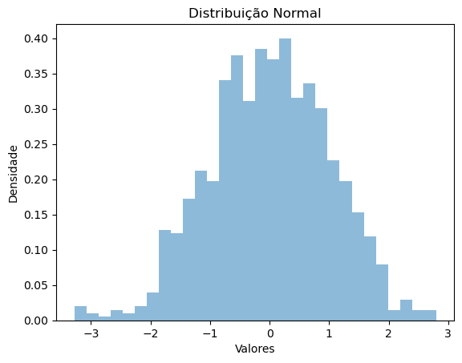

```python
import numpy as np
import matplotlib.pyplot as plt

# Gerar dados a partir de uma distribuição normal
mu = 0
sigma = 1
n_samples = 1000
data = np.random.normal(mu, sigma, n_samples)

# Plotar histograma dos dados
plt.hist(data, bins=30, density=True, alpha=0.5)
plt.xlabel('Valores')
plt.ylabel('Densidade')
plt.title('Distribuição Normal')
plt.show()
```

##### Distribuição Exponencial

A distribuição exponencial descreve o tempo entre eventos em um processo de Poisson, onde os eventos ocorrem independentemente com uma taxa média λ. A função densidade de probabilidade (FDP) de uma variável aleatória com distribuição exponencial é dada por: $$ f(x) = λ * exp(-λx) $$ onde x é o tempo entre eventos e λ é a taxa média de ocorrência.

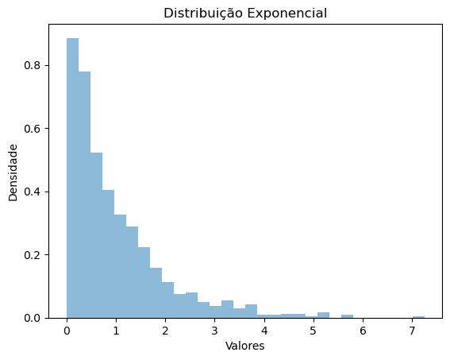

```python
import numpy as np
import matplotlib.pyplot as plt

# Gerar dados a partir de uma distribuição normal
mu = 1
n_samples = 1000
data = np.random.exponential(mu, n_samples)

# Plotar histograma dos dados
plt.hist(data, bins=30, density=True, alpha=0.5)
plt.xlabel('Valores')
plt.ylabel('Densidade')
plt.title('Distribuição Exponencial')
plt.show()
```

## Introdução à Estatística

A estatística é uma disciplina que envolve a coleta, análise, interpretação e apresentação de dados. Ela fornece métodos e técnicas para descrever e inferir informações sobre uma população com base em uma amostra observada.

### População e Amostra

Na estatística, trabalhamos com duas principais unidades de estudo: população e amostra. A população é o conjunto completo de elementos ou indivíduos que queremos estudar, enquanto a amostra é uma parte representativa da população que é selecionada para análise.

### Estatística Descritiva

A estatística descritiva envolve a organização, resumo e interpretação dos dados observados. Alguns conceitos importantes na estatística descritiva incluem:

#### Média

A média é uma medida de tendência central que representa o valor médio de um conjunto de dados. Para uma amostra, a média é denotada por x-barra (x̄), enquanto que para uma população, é denotada por μ (mu). A fórmula para calcular a média amostral é: $$ x̄ = (x₁ + x₂ + ... + xₙ) / n $$ onde $x₁, x₂, ..., xₙ$ são os valores observados e n é o tamanho da amostra.

#### Variância e Desvio Padrão

A variância mede a dispersão dos dados em relação à média. O desvio padrão é a raiz quadrada da variância e também é uma medida de dispersão. Para uma amostra, a variância é denotada por s², enquanto que para uma população, é denotada por σ². A fórmula para calcular a variância amostral é:

$$ s² = Σ(xᵢ - x̄)² / (n - 1) $$

onde xᵢ são os valores observados, x̄ é a média amostral e n é o tamanho da amostra.

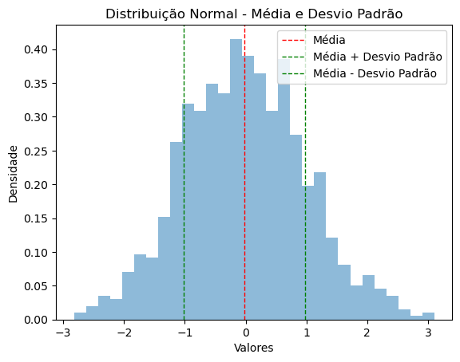

```python
import numpy as np
import matplotlib.pyplot as plt

# Gerar dados aleatórios com média 0 e desvio padrão 1
data = np.random.normal(0, 1, 1000)

# Calcular a média e o desvio padrão
mean = np.mean(data)
std = np.std(data)

# Plotar histograma dos dados
plt.hist(data, bins=30, density=True, alpha=0.5)
plt.xlabel('Valores')
plt.ylabel('Densidade')
plt.title('Distribuição Normal - Média e Desvio Padrão')
plt.axvline(mean, color='r', linestyle='dashed', linewidth=1, label='Média')
plt.axvline(mean + std, color='g', linestyle='dashed', linewidth=1, label='Média + Desvio Padrão')
plt.axvline(mean - std, color='g', linestyle='dashed', linewidth=1, label='Média - Desvio Padrão')
plt.legend()
plt.show()
```

#### Covariância e Coeficiente de Correlação

A covariância mede o grau de interdependência linear entre duas variáveis. A covariância amostral é denotada por sxy para uma amostra e a covariância populacional é denotada por σxy para uma população. O coeficiente de correlação é uma medida padronizada da covariância e varia de -1 a 1. Uma correlação próxima de 1 indica uma forte relação positiva, enquanto uma correlação próxima de -1 indica uma forte relação negativa. O coeficiente de correlação amostral é denotado por r para uma amostra e o coeficiente de correlação populacional é denotado por ρ para uma população.

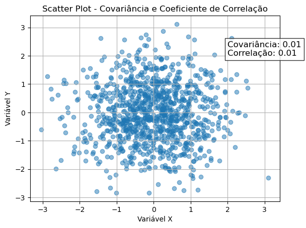

```python
import numpy as np
import matplotlib.pyplot as plt

# Gerar dados aleatórios para duas variáveis
x = np.random.normal(0, 1, 1000)
y = np.random.normal(0, 1, 1000)

# Calcular a covariância e o coeficiente de correlação
covariance = np.cov(x, y)[0, 1]
correlation = np.corrcoef(x, y)[0, 1]

# Plotar scatter plot dos dados
plt.scatter(x, y, alpha=0.5)
plt.xlabel('Variável X')
plt.ylabel('Variável Y')
plt.title('Scatter Plot - Covariância e Coeficiente de Correlação')
plt.text(2, 2, f'Covariância: {covariance:.2f}\nCorrelação: {correlation:.2f}', fontsize=12, bbox={'facecolor': 'white', 'alpha': 0.8})
plt.grid(True)
plt.show()
```

### Estatística Inferencial

#### Estimadores

Um estimador é uma função ou estatística calculada a partir dos dados da amostra e usada para estimar um parâmetro desconhecido da população. Um estimador pontual fornece uma única estimativa do parâmetro.

Alguns estimadores comuns incluem:

- **Média Amostral**: O estimador da média populacional é a média amostral, x̄.
- **Variância Amostral**: O estimador da variância populacional é a variância amostral, s².
- **Covariância Amostral**: O estimador da covariância populacional é a covariância amostral, sxy.

Um estimador é avaliado quanto às suas propriedades desejáveis, como viés (quão próximo ele está do valor verdadeiro do parâmetro), consistência (se converge para o valor verdadeiro à medida que o tamanho da amostra aumenta) e eficiência (quão precisamente ele estima o parâmetro).

#### Estimadores de Máxima Verossimilhança

Os estimadores de máxima verossimilhança são obtidos maximizando a função de verossimilhança, que mede a probabilidade de obter os dados observados para diferentes valores do parâmetro desconhecido. Esses estimadores são amplamente utilizados devido às suas propriedades estatísticas favoráveis.

Dado um conjunto de dados observados x₁, x₂, ..., xₙ, assumindo que as observações são independentes e identicamente distribuídas (i.i.d.) de acordo com uma distribuição de probabilidade parametrizada por θ, a função de verossimilhança L(θ) é definida como o produto das funções de densidade de probabilidade (f(xᵢ; θ)) correspondentes a cada observação:

$$ L(θ) = f(x₁; θ) * f(x₂; θ) * ... * f(xₙ; θ) $$

A ideia é encontrar o valor do parâmetro θ que maximiza a função de verossimilhança, ou seja, o valor que torna os dados observados mais prováveis de acordo com a distribuição especificada por θ.

Em muitos casos, é mais conveniente trabalhar com o logaritmo natural da função de verossimilhança (log-verossimilhança), que simplifica os cálculos e não altera a posição do máximo. Portanto, a log-verossimilhança é dada por:

$$ log L(θ) = log f(x₁; θ) + log f(x₂; θ) + ... + log f(xₙ; θ) $$

A estimação de máxima verossimilhança (EMV) envolve encontrar o valor de θ que maximiza a log-verossimilhança. Isso pode ser feito através de técnicas de otimização, como o método do gradiente ou métodos iterativos como o algoritmo de Newton-Raphson.

## Espaço Vetorial de Variáveis Aleatórias

No contexto da estatística, podemos considerar as variáveis aleatórias como vetores em um espaço vetorial. Isso nos permite explorar propriedades e operações matemáticas com as variáveis aleatórias de forma mais estruturada. Neste espaço, as variáveis aleatórias são tratadas como objetos matemáticos e podem ser manipuladas usando as regras do álgebra linear.

### Variáveis Aleatórias como Vetores

Uma variável aleatória pode ser vista como um vetor em um espaço vetorial. O espaço vetorial das variáveis aleatórias possui duas principais operações: adição e multiplicação por um escalar.

- **Adição**: A adição de variáveis aleatórias é realizada componente por componente. Dadas duas variáveis aleatórias X e Y, a soma das variáveis aleatórias é dada por:

$$ (X + Y)(x) = X(x) + Y(x) $$

onde x é um valor específico da variável aleatória.

- **Multiplicação por Escalar**: A multiplicação de uma variável aleatória por um escalar é feita multiplicando cada componente pela constante. Dada uma variável aleatória X e um escalar c, a multiplicação da variável aleatória por um escalar é dada por:

$$ (cX)(x) = c * X(x) $$

onde x é um valor específico da variável aleatória.

### Vetor Aleatório

Em estatística, um vetor aleatório é uma generalização de uma variável aleatória para múltiplas dimensões. Formalmente, um vetor aleatório é uma função que mapeia um espaço amostral em um espaço vetorial. Um vetor aleatório pode ser representado por uma matriz, onde cada linha ou coluna representa uma variável aleatória.

#### Definição Matemática

Seja X um vetor aleatório com dimensões d x 1, onde d é o número de variáveis aleatórias no vetor. Podemos definir um vetor aleatório como uma função que associa um vetor numérico a cada ponto amostral ω do espaço amostral Ω:

$$ X(ω) = [X₁(ω), X₂(ω), ..., X_d(ω)]^T $$

onde Xᵢ(ω) é a i-ésima variável aleatória no vetor e ω é um ponto no espaço amostral.

#### Distribuição Normal Vetorial

A distribuição normal multivariada (ou distribuição normal vetorial) é uma das distribuições mais importantes para vetores aleatórios. Uma distribuição normal vetorial é caracterizada por sua média vetorial e sua matriz de covariância.

Seja X um vetor aleatório d-dimensional com média μ e matriz de covariância Σ. A distribuição normal vetorial é denotada por:

$$ X \sim N(μ, Σ) $$

A função de densidade de probabilidade (PDF) da distribuição normal vetorial é dada por:

$$ f(x; μ, Σ) = (2π)^(-d/2) * |Σ|^(-1/2) * exp(-0.5 * (x - μ)^T * Σ^(-1) * (x - μ)) $$

onde x é o valor do vetor aleatório, μ é a média vetorial, Σ é a matriz de covariância, e |Σ| representa o determinante de Σ.

#### Deducao da Distribuição Normal Vetorial

A distribuição normal vetorial pode ser provada usando a função característica e a técnica de transformação linear. Aqui, forneceremos um esboço da prova.

Dado um vetor onde cada componente é uma variável aleatória X ~ N(0, 1), a pdf da v.a é dada por: $$ \begin{align} f(x) = \frac{1}{\sigma \sqrt{2\pi}} \, e^{-\frac{1}{2}\left(\frac{x-\mu}{\sigma}\right)^2} \end{align} $$ Logo, se todas as componentes são v.a I.I.D da mesma distribuição a distribuição conjunta delas é $$ \begin{align}%\label{} f_{\mathbf{Z}}(\mathbf{z})&=f_{Z_1, Z_2, ..., Z_n}(z_1, z_2, ..., z_n)\\ &=\prod_{i=1}^{n} f_{Z_i}(z_i)\\ &=\frac{1}{(2\pi)^{\frac{n}{2}}} \exp \left\{-\frac{1}{2} \sum_{i=1}^{n} z_i^2 \right\}\\ &=\frac{1}{(2\pi)^{\frac{n}{2}}} \exp \left\{-\frac{1}{2} \mathbf{z}^T\mathbf{z} \right\}. \end{align} $$

Da álgebra linear, sabemos que existe uma matriz $Q$ de dimensão $n \times n$ tal que: $Q \cdot Q^T = I$ (I é a matriz identidade) $C = Q \cdot D \cdot Q^T$,

onde $D$ é uma matriz diagonal: $D = \begin{bmatrix} d_{11} & 0 & \ldots & 0 \\ 0 & d_{22} & \ldots & 0 \\ \vdots & \vdots & \ddots & \vdots \\ 0 & 0 & \ldots & d_{nn} \end{bmatrix}$,

e os $d_{ii}$ são todos positivos. Definimos ainda: $D_{12} = \begin{bmatrix} \sqrt{d_{11}} & 0 & \ldots & 0 \\ 0 & \sqrt{d_{22}} & \ldots & 0 \\ \vdots & \vdots & \ddots & \vdots \\ 0 & 0 & \ldots & \sqrt{d_{nn}} \end{bmatrix}$,

de modo que $D_{12} \cdot D_{12} = D$ e $D_{12} = D_{12}^T$. Definimos também: $A = Q \cdot D_{12} \cdot Q^T$.

Dessa forma, $A \cdot A^T = A^T \cdot A = C$.

Agora estamos prontos para definir a transformação que converte um vetor gaussiano padrão em $X \sim N(m, C)$. Seja $Z$ um vetor gaussiano padrão, ou seja, $Z \sim N(0, I)$. Definimos: $X = A \cdot Z + m$.

Afirmamos que $X \sim N(m, C)$. Para ver isso, observe primeiramente que $X$ é um vetor aleatório normal. A razão é que qualquer combinação linear dos componentes de $X$ é, na verdade, uma combinação linear dos componentes de $Z$ mais uma constante. Assim, toda combinação linear dos componentes de $X$ é uma variável aleatória normal. Resta mostrar que $\mathbb{E}[X] = m$ e $\mathbb{Cov}[X] = C$. Primeiro, observe que pela linearidade da expectativa temos: $\mathbb{E}[X] = \mathbb{E}[A \cdot Z + m] = A \cdot \mathbb{E}[Z] + m = m$.

Portanto, mostramos que $X$ é um vetor aleatório com média $m$ e matriz de covariância $C$. Agora podemos usar sua inversa para encontrar a função densidade de probabilidade (PDF) de $X$. Temos: $f_X(x) = \frac{1}{\lvert \det(A) \rvert} \cdot f_Z(A^{-1}(x - m)) = \frac{1}{{(2\pi)^{n/2}} \sqrt{\det(C)}} \cdot \exp\left\{-\frac{1}{2}(x - m)^T \cdot C^{-1} \cdot (x - m)\right\}$.

### Ilustracao Visual

Vamos ilustrar como se apresentam no espaço os pontos determinados por vetores aleatórios.

Primeiro, vamos gerar uma variável aleatória X a partir de uma distribuição normal com média 0 e desvio padrão 1:

```python
import numpy as np
import matplotlib.pyplot as plt

# Número de vetores aleatórios a serem gerados
n_vectors = 1000

# Gerar matriz de variáveis aleatórias com distribuição normal
mu = 0
sigma = 1
X = np.random.normal(mu, sigma, size=(2, n_vectors))
```

Agora, vamos plotar os vetores aleatórios no espaço R²:

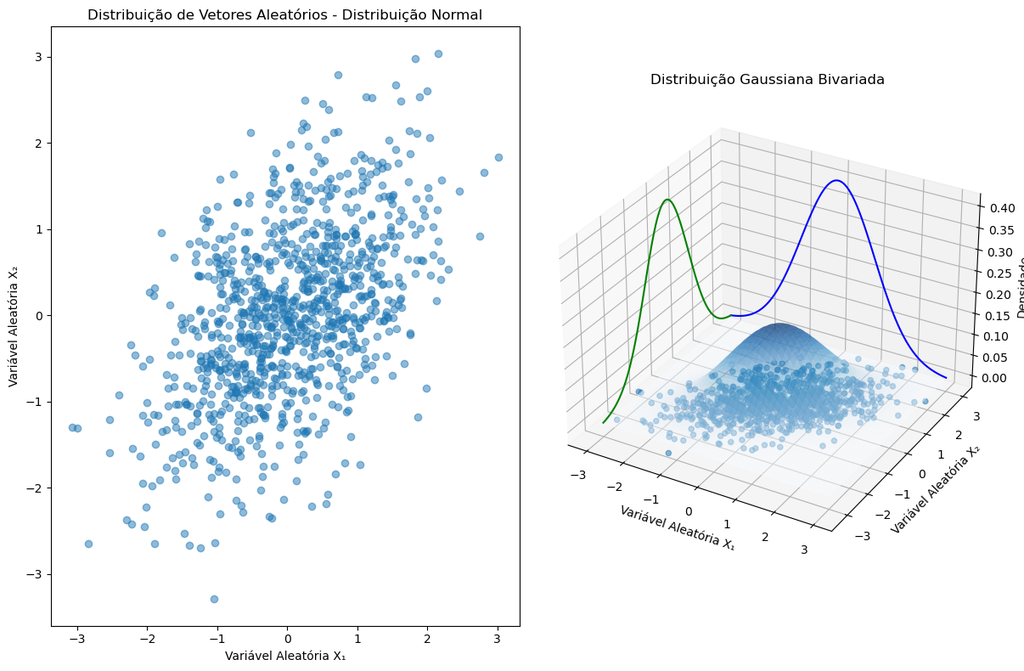

```python
import numpy as np
import matplotlib.pyplot as plt
from scipy.stats import multivariate_normal
from scipy.stats import norm

# Set random seed for reproducibility
np.random.seed(0)

# Generate synthetic data
mean = [0, 0]
cov = [[1, 0.5], [0.5, 1]]
X = np.random.multivariate_normal(mean, cov, size=1000)

# Plotting
fig = plt.figure(figsize=(12, 8))
ax = fig.add_subplot(1,2,2, projection='3d')

# Scatter plot on the floor
ax.scatter(X[:, 0], X[:, 1], np.zeros_like(X[:, 0]), alpha=0.5)
ax.set_xlabel('Variável Aleatória X₁')
ax.set_ylabel('Variável Aleatória X₂')
ax.set_zlabel('Piso')
ax.set_title('Distribuição de Vetores Aleatórios - Distribuição Normal (Piso)')

# 3D Gaussian contours on the walls
x = np.linspace(-3, 3, 100)
y = np.linspace(-3, 3, 100)
X_axis, Y_axis = np.meshgrid(x, y)
Z = multivariate_normal.pdf(np.column_stack((X_axis.flatten(), Y_axis.flatten())), mean, cov)
Z = Z.reshape(X_axis.shape)
ax.plot_surface(X_axis, Y_axis, Z, alpha=0.5, cmap='Blues', edgecolor='none')

# X1 PDF along the X-axis
x1 = np.linspace(-3, 3, 100)
y = np.ones_like(x1)*3
z1 = norm.pdf(x1, mean[0], np.sqrt(cov[0][0]))
ax.plot(x1, y, z1, color='b')

# X2 PDF along the Y-axis
x = np.ones_like(x1)*-3
y2 = np.linspace(-3, 3, 100)
z2 = norm.pdf(y2, mean[1], np.sqrt(cov[1][1]))
ax.plot(x, y2, z2, color='g')

# Set labels and title
ax.set_xlabel('Variável Aleatória X₁')
ax.set_ylabel('Variável Aleatória X₂')
ax.set_zlabel('Densidade')
ax.set_title('Distribuição Gaussiana Bivariada')

#Only the scatter
ax2 = fig.add_subplot(1,2,1)
# Scatter plot on the floor
ax2.scatter(X[:, 0], X[:, 1], alpha=0.5)
ax2.set_xlabel('Variável Aleatória X₁')
ax2.set_ylabel('Variável Aleatória X₂')
ax2.set_title('Distribuição de Vetores Aleatórios - Distribuição Normal')

plt.tight_layout()
plt.show()
```

Esse código irá gerar uma visualização com vários vetores aleatórios no espaço R², onde cada coordenada representa o valor de uma variável aleatória. A dispersão dos vetores demonstra como a distribuição normal se parece no espaço vetorial de variáveis aleatórias.

Agora, vamos repetir o processo utilizando a distribuição uniforme:

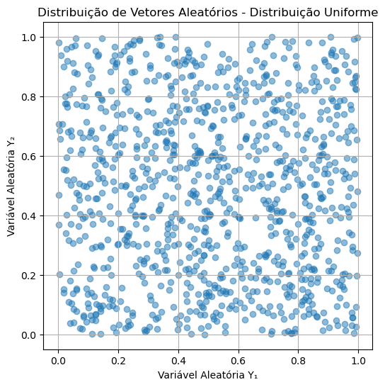

```python
# Gerar matriz de variáveis aleatórias com distribuição uniforme
low = 0
high = 1
Y = np.random.uniform(low, high, size=(2, n_vectors))

# Plotar vetores aleatórios
plt.figure(figsize=(6, 6))
plt.scatter(Y[0, :], Y[1, :], alpha=0.5)
plt.xlabel('Variável Aleatória Y₁')
plt.ylabel('Variável Aleatória Y₂')
plt.title('Distribuição de Vetores Aleatórios - Distribuição Uniforme')
plt.grid(True)
plt.show()
```

## PCA e SVD: Análise de Componentes Principais e Decomposição em Valores Singulares

### PCA (Análise de Componentes Principais)

PCA é uma técnica que busca encontrar uma representação de baixa dimensionalidade dos dados originais, capturando a maior quantidade possível de variabilidade dos dados. Isso é alcançado através da identificação dos componentes principais, que são combinações lineares das variáveis originais.

#### Formulação Matemática

Dado um conjunto de dados X com n amostras e p variáveis, podemos realizar a PCA da seguinte forma:

1. Centralize os dados: Calcule a média de cada variável e subtraia a média de cada amostra.
2. Calcule a matriz de covariância: A matriz de covariância captura as relações entre as variáveis originais.
3. Calcule os autovetores e autovalores: Aplique a decomposição espectral na matriz de covariância para obter os autovetores e autovalores.
4. Escolha os componentes principais: Selecione os autovetores com os maiores autovalores como componentes principais.
5. Projete os dados nos componentes principais: Multiplique a matriz centralizada dos dados pelos autovetores selecionados para obter a projeção dos dados em um novo espaço.

#### Ilustracao Visual

Vamos realizar uma ilustracao do PCA usando o conjunto de dados Iris. Usaremos a biblioteca scikit-learn para carregar o conjunto de dados e realizar o PCA.

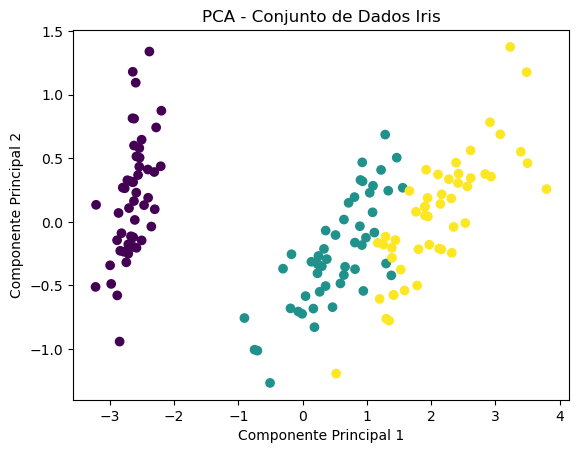

```python
import numpy as np
import matplotlib.pyplot as plt
from sklearn.datasets import load_iris
from sklearn.decomposition import PCA

# Carregar o conjunto de dados Iris
iris = load_iris()
X = iris.data
y = iris.target

# Aplicar a PCA
pca = PCA(n_components=2)
X_pca = pca.fit_transform(X)

# Plotar os dados projetados nos dois primeiros componentes principais
plt.scatter(X_pca[:, 0], X_pca[:, 1], c=y)
plt.xlabel('Componente Principal 1')
plt.ylabel('Componente Principal 2')
plt.title('PCA - Conjunto de Dados Iris')
plt.show()
```

### SVD (Decomposição em Valores Singulares)

SVD é uma técnica que permite a decomposição de uma matriz em três componentes: uma matriz de vetores singulares esquerda, uma matriz de valores singulares e uma matriz de vetores singulares direita. Essa decomposição é útil para entender a estrutura dos dados e realizar operações como reconstrução, redução de dimensionalidade e filtragem de ruído.

Dada uma matriz X de dimensões m × n, a SVD é dada por:

X = U *S* V^T

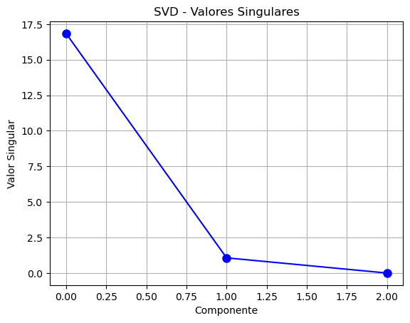

```python
import numpy as np
import matplotlib.pyplot as plt

# Gerar uma matriz de exemplo
X = np.array([[1, 2, 3], [4, 5, 6], [7, 8, 9]])

# Calcular a SVD
U, S, Vt = np.linalg.svd(X)

# Plotar os valores singulares
plt.plot(S, 'bo-', markersize=8)
plt.xlabel('Componente')
plt.ylabel('Valor Singular')
plt.title('SVD - Valores Singulares')
plt.grid(True)
plt.show()
```

### Relação entre PCA e SVD

PCA (Principal Component Analysis) e SVD (Singular Value Decomposition) estão intimamente relacionados e compartilham conceitos fundamentais. De fato, a PCA pode ser vista como uma aplicação especial da SVD em uma matriz de covariância.

#### PCA como uma Aplicação da SVD

Dada uma matriz de dados X de dimensões n x p, onde n é o número de amostras e p é o número de variáveis, a PCA busca encontrar uma base ortogonal de p componentes principais que capture a maior variabilidade dos dados. Essa base de componentes principais é composta pelos autovetores da matriz de covariância dos dados.

A matriz de covariância dos dados é dada por:

$ C = (1/n) * X^T * X $

onde X^T é a matriz transposta de X.

Podemos então realizar a decomposição espectral na matriz de covariância C para obter os autovetores (V) e autovalores (λ). Os autovetores representam a direção dos componentes principais, enquanto os autovalores indicam a importância dessas direções.

A matriz de projeção dos dados nos componentes principais, Z, é obtida multiplicando a matriz de dados X pelos autovetores selecionados:

$ Z = X * V $

Essa matriz Z representa os dados projetados nos componentes principais. Portanto, podemos ver que a PCA pode ser interpretada como uma aplicação da SVD na matriz de covariância.

#### Relação Matemática entre PCA e SVD

Podemos estabelecer uma relação matemática entre a PCA e a SVD ao comparar as equações da PCA e da SVD.

Na PCA, a matriz de dados X pode ser decomposta como:

$ X = Z * V^T $

onde Z é a matriz dos dados projetados nos componentes principais e V^T é a matriz transposta dos autovetores selecionados.

Por outro lado, a SVD da matriz de dados X é dada por:

$ X = U * S * V^T $

onde U é a matriz dos autovetores esquerda, S é a matriz diagonal dos valores singulares e V^T é a matriz transposta dos autovetores direita.

Ao comparar essas duas equações, podemos concluir que a matriz dos autovetores esquerda da SVD (U) é equivalente à matriz dos dados projetados nos componentes principais (Z) da PCA. Além disso, os valores singulares (S) da SVD correspondem aos autovalores (λ) da PCA.

Essa relação estabelece a equivalência conceitual entre PCA e SVD, mostrando que os autovetores e autovalores da PCA são obtidos através da SVD da matriz de covariância dos dados.

## Regressão Linear e o estimador de mínimos quadrados

### Introdução à Regressão Linear em Termos Estatísticos

A regressão linear é uma técnica estatística que visa modelar a relação entre uma variável dependente e uma ou mais variáveis independentes. Essa relação pode ser expressa através de uma equação linear. Em termos de álgebra linear, a regressão linear pode ser formulada como um problema de encontrar uma combinação linear ótima dos vetores de características para prever o valor da variável dependente.

O objetivo da regressão linear é encontrar os coeficientes que minimizam a soma dos erros quadrados entre os valores observados e os valores previstos pelo modelo linear. Esses coeficientes são estimados usando o método dos mínimos quadrados. No entanto, a regressão linear padrão não considera a multicolinearidade, que ocorre quando as variáveis independentes estão altamente correlacionadas entre si. Além disso, a regressão linear pode sofrer de overfitting quando há muitas variáveis independentes.

### Função de Custo da Regressão Linear e Máxima Verossimilhança

A função de custo da regressão linear é derivada a partir da abordagem da máxima verossimilhança. A ideia básica é encontrar os coeficientes que maximizam a probabilidade de observar os valores observados dado o modelo linear. Supomos que os erros entre os valores observados e os valores previstos sigam uma distribuição normal com média zero e variância constante. Logo é fácil ver que $ E(Y) = \theta^T x$ pelas propriedades da esperança, logo a regressão pode ser encarado como a média da distribuição de y

Dado um conjunto de dados de treinamento composto por pares de valores (x, y), onde x é o vetor de características e y é o valor observado, a probabilidade de observar os valores y dado o modelo linear é dada pela função de densidade de probabilidade (PDF) da distribuição normal:

$$P(y|x, \theta) = \frac{1}{\sqrt{2\pi}\sigma}e^{-\frac{(y - \theta^Tx)^2}{2\sigma^2}}$$

onde $\theta$ é o vetor de coeficientes e $\sigma$ é o desvio padrão dos erros. A função de verossimilhança é o produto das probabilidades individuais de cada valor observado. Como é mais conveniente maximizar a função de verossimilhança, tomamos o logaritmo da função de verossimilhança para obter a função de log-verossimilhança:

$$ L(\theta) = \prod_{i=1}^{n} P(y|x, \theta)$$$$\log L(\theta) = -\frac{n}{2}\log(2\pi) - n\log\sigma - \frac{1}{2\sigma^2}\sum_{i=1}^{n}(y_i - \theta^Tx_i)^2$$

onde n é o número de observações. O objetivo é encontrar o vetor de coeficientes $\theta$ que maximiza a função de log-verossimilhança.

A função de custo da regressão linear é definida como o negativo da função de log-verossimilhança, multiplicado por -1 para transformar o problema de maximização em minimização:

$$J(\theta) = \frac{1}{2}\sum_{i=1}^{n}(y_i - \theta^Tx_i)^2$$

Essa é a função de custo que queremos minimizar para encontrar os coeficientes ótimos da regressão linear.

Note que em estatística fala-se de estimadores, ou seja, um valor dependente das observações que espera estimar o valor do parametro real. Nesse caso, o valor dos coeficientes reais seria $\theta$, porém como desconhecemos esse valor buscamos aproximar $\theta$ por um estimador $\^\theta$ que é encontrado a partir da minimização da função de custo, esse estimador é chamado de estimador dos mínimos quadrados pois é derivado da forma dos mínimos quadrados da álgebra

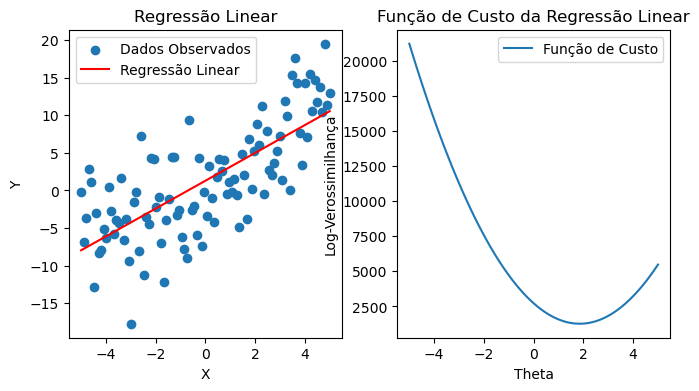

```python
import numpy as np
import matplotlib.pyplot as plt

np.random.seed(0)

# Gerando dados sintéticos
X = np.linspace(-5, 5, 100)
noise = np.random.normal(0, 5, size=100)
Y = 2*X + 1 + noise

# Gerando valores previstos
Y_pred = 2*X + 1

# Calculando coeficientes da regressão linear
X_matrix = np.column_stack((np.ones_like(X), X))
coefficients_normal = np.linalg.inv(X_matrix.T @ X_matrix) @ X_matrix.T @ Y


# Gerando valores thetas para função custo
theta_values = np.linspace(-5, 5, 100)
cost_values = [(1/2)*np.sum((Y - theta*X - 1)**2) for theta in theta_values]

# Gerando valores lambda para regressão ridge
lambda_values = np.linspace(0, 100, 100)
coefficient_values = []
for lam in lambda_values:
    X_matrix = np.column_stack((np.ones_like(X), X))
    coefficient = np.linalg.inv(X_matrix.T @ X_matrix + lam*np.eye(2)) @ X_matrix.T @ Y
    coefficient_values.append(coefficient)

# Plotting
plt.figure(figsize=(12, 4))
Y_normal = coefficients_normal[0] + coefficients_normal[1]*X
plt.subplot(1, 3, 1)
plt.title("Regressão Linear")
plt.xlabel("X")
plt.ylabel("Y")
plt.scatter(X, Y, label="Dados Observados")
plt.plot(X, Y_normal, color='red', label="Regressão Linear")
plt.legend()

plt.subplot(1, 3, 2)
plt.title("Função de Custo da Regressão Linear")
plt.xlabel("Theta")
plt.ylabel("Log-Verossimilhança")
plt.plot(theta_values, cost_values, label="Função de Custo")
plt.legend()
```

## Regressão Ridge (Tikhonov Regularization)

A regressão ridge, também conhecida como regularização de Tikhonov, é uma extensão da regressão linear que introduz um termo de penalidade na função objetivo da regressão linear. O objetivo é minimizar a soma dos erros quadrados, ao mesmo tempo em que reduz o impacto da multicolinearidade e evita o overfitting.

Na regressão ridge, adicionamos um termo de penalidade que encolhe os coeficientes em direção a zero:

$$J(\theta) = \frac{1}{2}\sum_{i=1}^{n}(y_i - \theta^Tx_i)^2 + \lambda\sum_{j=1}^{p}\theta_j^2$$

onde $\lambda$ é o parâmetro de regularização e p é o número de características. O termo de penalidade $\lambda\sum_{j=1}^{p}\theta_j^2$ desencoraja coeficientes grandes, reduzindo efetivamente o impacto da multicolinearidade.

A solução da regressão ridge pode ser obtida através da derivação da função de custo em relação aos coeficientes $\theta$ e igualando a zero:

$$\nabla J(\theta) = X^T(X\theta - y) + \lambda \theta = 0$$

Simplificando a equação:

$$X^TX\theta + \lambda \theta = X^Ty$$

Rearranjando os termos:

$$(X^TX + \lambda I)\theta = X^Ty$$

Para obter a solução ótima para a regressão ridge, resolvemos para $\theta$ isolando-o no lado esquerdo da equação:

$$\theta = (X^TX + \lambda I)^{-1}X^Ty$$

Esses são os coeficientes $\theta$ que minimizam a função de custo para a regressão ridge.

Na prática, em vez de calcular a inversa diretamente, podemos usar técnicas como a decomposição em valores singulares (SVD) ou a decomposição de Cholesky para calcular eficientemente a solução.

A regressão ridge ajuda a estabilizar o modelo e reduzir o impacto da multicolinearidade, adicionando uma penalidade aos coeficientes. O parâmetro de regularização $\lambda$ controla a quantidade de encolhimento aplicada aos coeficientes. Um $\lambda$ maior resulta em um encolhimento maior, reduzindo efetivamente a complexidade do modelo.

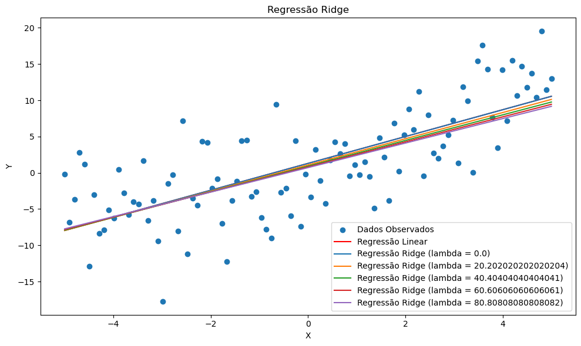

```python
# Ridge regression
plt.figure(figsize=(10, 6))
plt.scatter(X, Y, label="Dados Observados")
plt.plot(X, Y_normal, color='red', label="Regressão Linear")
for i in range(0,100,20):
    Y_ridge = coefficient_values[i][0] + coefficient_values[i][1]*X
    plt.plot(X, Y_ridge, label=f"Regressão Ridge (lambda = {lambda_values[i]})")
plt.title("Regressão Ridge")
plt.xlabel("X")
plt.ylabel("Y")
plt.legend()


plt.tight_layout()
plt.show()
```

## Referências

- Ross, S. M. (2019). A First Course in Probability (10th ed.). Pearson.
- Wackerly, D. D., Mendenhall III, W., & Scheaffer, R. L. (2014). Mathematical Statistics with Applications (7th ed.). Cengage Learning.
- Bishop, C. M. (2006). Pattern Recognition and Machine Learning. Springer.
- Hastie, T., Tibshirani, R., & Friedman, J. (2009). The Elements of Statistical Learning: Data Mining, Inference, and Prediction. Springer.
- Golub, G. H., & Van Loan, C. F. (2012). Matrix Computations. JHU Press.
- Ross, S. M. (2019). A First Course in Probability (10th ed.). Pearson.
- https://www.probabilitycourse.com/chapter6/6_1_5_random_vectors.php
- Pfeiffer, P. (2020) Probability, Mathematical Statistics, and Stochastic Processes (Siegrist) Rice University.